# HCD Simulations Write Up

Audrey Fu Lab

2024-03-07

We simulate hierarchical networks in a top-down approach. We consider several parameters of simulation such as sparsity, noise, and the architecture of the super level graph(s), namely small-world, and scale-free networks [@watts1998collective; @barabasi2003scale]. We simplify our simulations by focusing on basic hierarchies with just one or two hierarchical layers.

In each hierarchy, we start by simulating the top-level nodes in topological order, using either a small world or scale-free network structure [@watts1998collective; @barabasi2003scale]. We define origin nodes as nodes in the topological graph that have no parental input. All origin nodes are simulated from a standard normal distribtion. After generating an initial graph corresponding to the top most layer of the hierarchy, we simulate the middle and bottom layers of the hierarchy by creating groups of new nodes for each parent super-node in the upper level(s).

Each hierarchical level contains community structure nested in the previous layer. The number of offspring nodes generated for each parent node in the level above is chosen from a uniform $\text{unif}(a,b)$ distribution. We also control the connection probabilities both within and between the communities of each hierarchical layer. Once a hierarchical graph is simulated we use the hierarchy to generate the node-feature matrix which represents the expression of $N$ genes in $p$ samples. The number $N$ represents the number of nodes in the observed (bottom) layer of the hierarchy and ranges between $a^{\ell+1}<N<a\times b^\ell$ where $\ell$ represents the number of hierarchical layers.

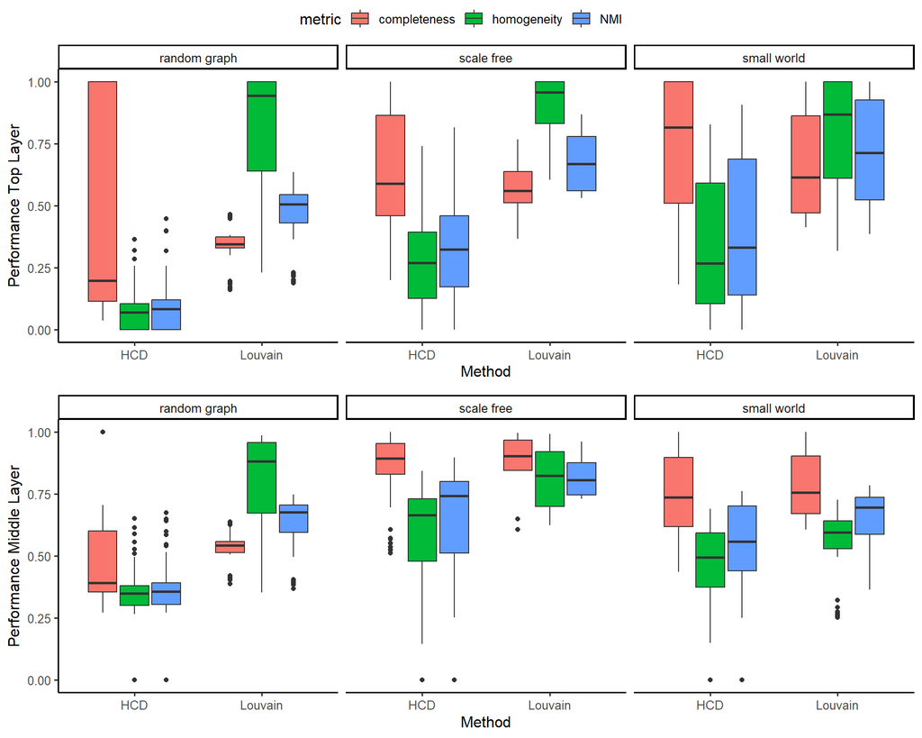

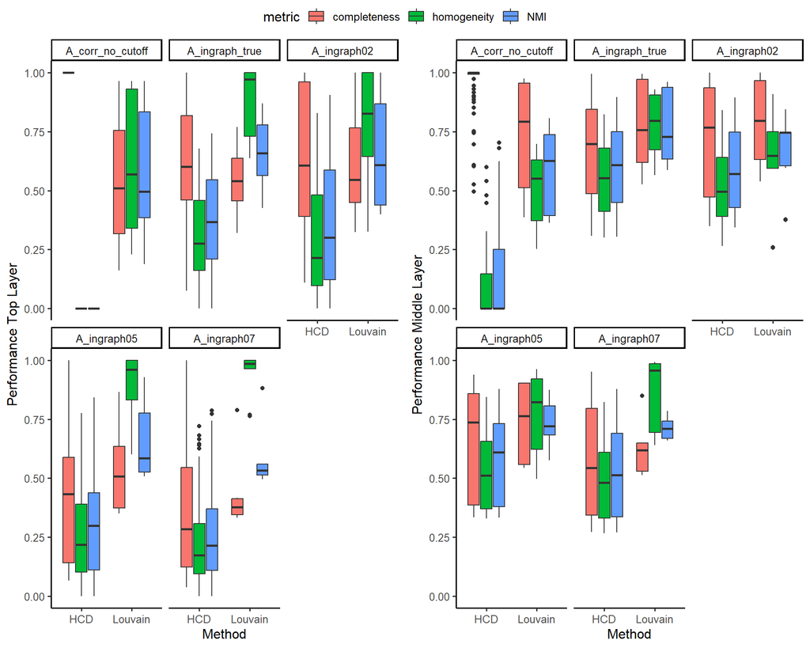

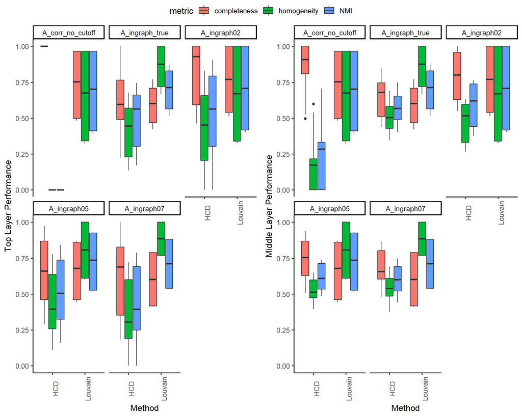

Small world graphs

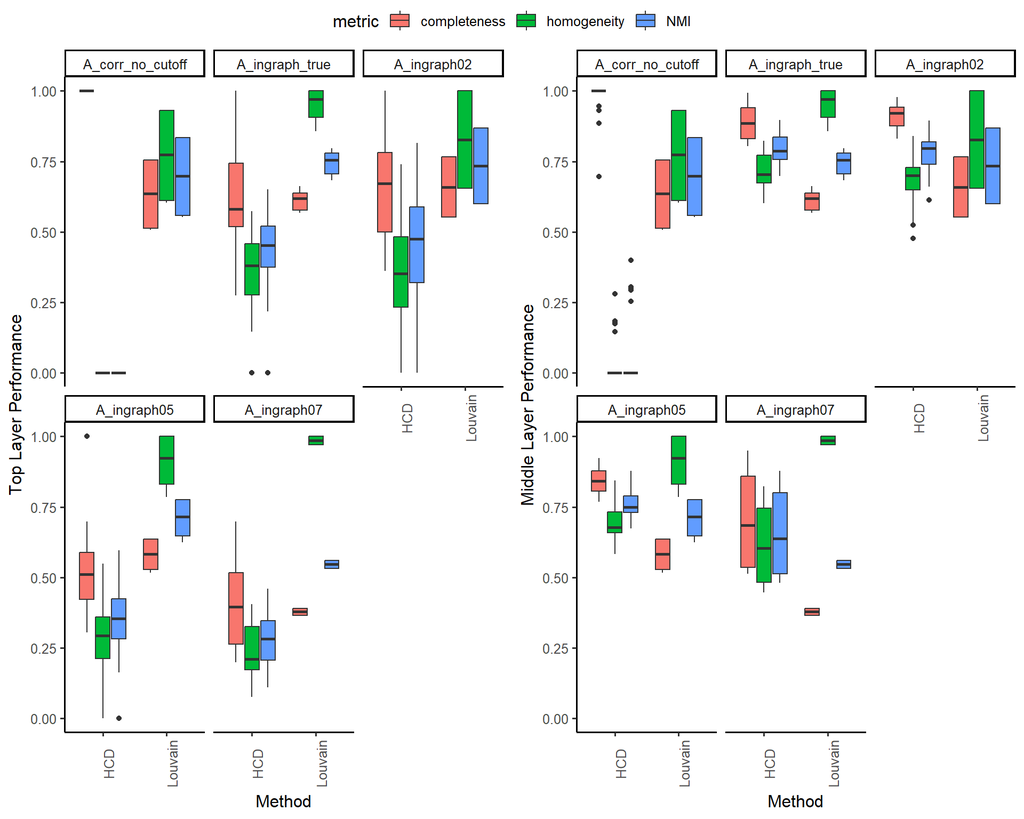

Scale free graphs

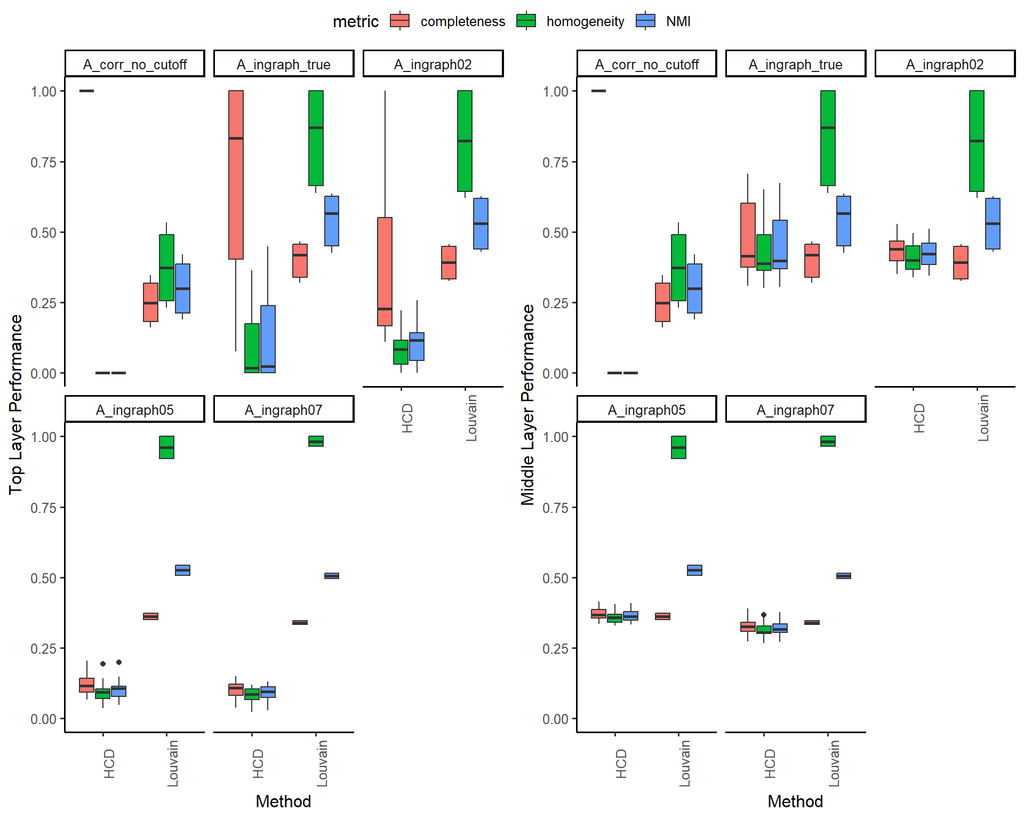

random graphs

| Scenario | Input Graph | Graph Recon. Loss | Attr. Recon. Loss | Modularity Weigth | Clust. Weight |
| --- | --- | --- | --- | --- | --- |
| 1 | A_ingraph_true | 1 = on | False (on) | 1 = on | 1 (middle), 1 (top) |
| 2 | A_corr_no_cutoff | 1 = on | False (on) | 1 = on | 1 (middle), 1 (top) |
| 3 | A_ingraph02 | 1 = on | False (on) | 1 = on | 1 (middle), 1 (top) |
| 4 | A_ingraph05 | 1 = on | False (on) | 1 = on | 1 (middle), 1 (top) |
| 5 | A_ingraph07 | 1 = on | False (on) | 1 = on | 1 (middle), 1 (top) |
| 6 | A_ingraph_true | 0 = off | False (on) | 1 = on | 1 (middle), 1 (top) |
| 7 | A_corr_no_cutoff | 0 = off | False (on) | 1 = on | 1 (middle), 1 (top) |
| 8 | A_ingraph02 | 0 = off | False (on) | 1 = on | 1 (middle), 1 (top) |
| 9 | A_ingraph05 | 0 = off | False (on) | 1 = on | 1 (middle), 1 (top) |
| 10 | A_ingraph07 | 0 = off | False (on) | 1 = on | 1 (middle), 1 (top) |
| 11 | A_ingraph_true | 1 = on | True (off) | 1 = on | 1 (middle), 1 (top) |
| 12 | A_corr_no_cutoff | 1 = on | True (off) | 1 = on | 1 (middle), 1 (top) |
| 13 | A_ingraph02 | 1 = on | True (off) | 1 = on | 1 (middle), 1 (top) |
| 14 | A_ingraph05 | 1 = on | True (off) | 1 = on | 1 (middle), 1 (top) |
| 15 | A_ingraph07 | 1 = on | True (off) | 1 = on | 1 (middle), 1 (top) |
| 16 | A_ingraph_true | 0 = off | True (off) | 1 = on | 1 (middle), 1 (top) |
| 17 | A_corr_no_cutoff | 0 = off | True (off) | 1 = on | 1 (middle), 1 (top) |
| 18 | A_ingraph02 | 0 = off | True (off) | 1 = on | 1 (middle), 1 (top) |
| 19 | A_ingraph05 | 0 = off | True (off) | 1 = on | 1 (middle), 1 (top) |
| 20 | A_ingraph07 | 0 = off | True (off) | 1 = on | 1 (middle), 1 (top) |
| 21 | A_ingraph_true | 1 = on | False (on) | 0 = off | 1 (middle), 1 (top) |
| 22 | A_corr_no_cutoff | 1 = on | False (on) | 0 = off | 1 (middle), 1 (top) |
| 23 | A_ingraph02 | 1 = on | False (on) | 0 = off | 1 (middle), 1 (top) |
| 24 | A_ingraph05 | 1 = on | False (on) | 0 = off | 1 (middle), 1 (top) |
| 25 | A_ingraph07 | 1 = on | False (on) | 0 = off | 1 (middle), 1 (top) |
| 26 | A_ingraph_true | 0 = off | False (on) | 0 = off | 1 (middle), 1 (top) |
| 27 | A_corr_no_cutoff | 0 = off | False (on) | 0 = off | 1 (middle), 1 (top) |
| 28 | A_ingraph02 | 0 = off | False (on) | 0 = off | 1 (middle), 1 (top) |
| 29 | A_ingraph05 | 0 = off | False (on) | 0 = off | 1 (middle), 1 (top) |
| 30 | A_ingraph07 | 0 = off | False (on) | 0 = off | 1 (middle), 1 (top) |
| 31 | A_ingraph_true | 1 = on | True (off) | 0 = off | 1 (middle), 1 (top) |
| 32 | A_corr_no_cutoff | 1 = on | True (off) | 0 = off | 1 (middle), 1 (top) |
| 33 | A_ingraph02 | 1 = on | True (off) | 0 = off | 1 (middle), 1 (top) |
| 34 | A_ingraph05 | 1 = on | True (off) | 0 = off | 1 (middle), 1 (top) |
| 35 | A_ingraph07 | 1 = on | True (off) | 0 = off | 1 (middle), 1 (top) |
| 36 | A_ingraph_true | 0 = off | True (off) | 0 = off | 1 (middle), 1 (top) |
| 37 | A_corr_no_cutoff | 0 = off | True (off) | 0 = off | 1 (middle), 1 (top) |
| 38 | A_ingraph02 | 0 = off | True (off) | 0 = off | 1 (middle), 1 (top) |
| 39 | A_ingraph05 | 0 = off | True (off) | 0 = off | 1 (middle), 1 (top) |
| 40 | A_ingraph07 | 0 = off | True (off) | 0 = off | 1 (middle), 1 (top) |
| 41 | A_ingraph_true | 1 = on | False (on) | 1 = on | 0.1 (middle), 1e-4 (top) |
| 42 | A_corr_no_cutoff | 1 = on | False (on) | 1 = on | 0.1 (middle), 1e-4 (top) |
| 43 | A_ingraph02 | 1 = on | False (on) | 1 = on | 0.1 (middle), 1e-4 (top) |
| 44 | A_ingraph05 | 1 = on | False (on) | 1 = on | 0.1 (middle), 1e-4 (top) |
| 45 | A_ingraph07 | 1 = on | False (on) | 1 = on | 0.1 (middle), 1e-4 (top) |
| 46 | A_ingraph_true | 0 = off | False (on) | 1 = on | 0.1 (middle), 1e-4 (top) |
| 47 | A_corr_no_cutoff | 0 = off | False (on) | 1 = on | 0.1 (middle), 1e-4 (top) |
| 48 | A_ingraph02 | 0 = off | False (on) | 1 = on | 0.1 (middle), 1e-4 (top) |
| 49 | A_ingraph05 | 0 = off | False (on) | 1 = on | 0.1 (middle), 1e-4 (top) |
| 50 | A_ingraph07 | 0 = off | False (on) | 1 = on | 0.1 (middle), 1e-4 (top) |
| 51 | A_ingraph_true | 1 = on | True (off) | 1 = on | 0.1 (middle), 1e-4 (top) |
| 52 | A_corr_no_cutoff | 1 = on | True (off) | 1 = on | 0.1 (middle), 1e-4 (top) |
| 53 | A_ingraph02 | 1 = on | True (off) | 1 = on | 0.1 (middle), 1e-4 (top) |
| 54 | A_ingraph05 | 1 = on | True (off) | 1 = on | 0.1 (middle), 1e-4 (top) |
| 55 | A_ingraph07 | 1 = on | True (off) | 1 = on | 0.1 (middle), 1e-4 (top) |
| 56 | A_ingraph_true | 0 = off | True (off) | 1 = on | 0.1 (middle), 1e-4 (top) |
| 57 | A_corr_no_cutoff | 0 = off | True (off) | 1 = on | 0.1 (middle), 1e-4 (top) |
| 58 | A_ingraph02 | 0 = off | True (off) | 1 = on | 0.1 (middle), 1e-4 (top) |
| 59 | A_ingraph05 | 0 = off | True (off) | 1 = on | 0.1 (middle), 1e-4 (top) |
| 60 | A_ingraph07 | 0 = off | True (off) | 1 = on | 0.1 (middle), 1e-4 (top) |
| 61 | A_ingraph_true | 1 = on | False (on) | 0 = off | 0.1 (middle), 1e-4 (top) |
| 62 | A_corr_no_cutoff | 1 = on | False (on) | 0 = off | 0.1 (middle), 1e-4 (top) |
| 63 | A_ingraph02 | 1 = on | False (on) | 0 = off | 0.1 (middle), 1e-4 (top) |
| 64 | A_ingraph05 | 1 = on | False (on) | 0 = off | 0.1 (middle), 1e-4 (top) |
| 65 | A_ingraph07 | 1 = on | False (on) | 0 = off | 0.1 (middle), 1e-4 (top) |
| 66 | A_ingraph_true | 0 = off | False (on) | 0 = off | 0.1 (middle), 1e-4 (top) |
| 67 | A_corr_no_cutoff | 0 = off | False (on) | 0 = off | 0.1 (middle), 1e-4 (top) |
| 68 | A_ingraph02 | 0 = off | False (on) | 0 = off | 0.1 (middle), 1e-4 (top) |
| 69 | A_ingraph05 | 0 = off | False (on) | 0 = off | 0.1 (middle), 1e-4 (top) |
| 70 | A_ingraph07 | 0 = off | False (on) | 0 = off | 0.1 (middle), 1e-4 (top) |
| 71 | A_ingraph_true | 1 = on | True (off) | 0 = off | 0.1 (middle), 1e-4 (top) |
| 72 | A_corr_no_cutoff | 1 = on | True (off) | 0 = off | 0.1 (middle), 1e-4 (top) |
| 73 | A_ingraph02 | 1 = on | True (off) | 0 = off | 0.1 (middle), 1e-4 (top) |
| 74 | A_ingraph05 | 1 = on | True (off) | 0 = off | 0.1 (middle), 1e-4 (top) |
| 75 | A_ingraph07 | 1 = on | True (off) | 0 = off | 0.1 (middle), 1e-4 (top) |
| 76 | A_ingraph_true | 0 = off | True (off) | 0 = off | 0.1 (middle), 1e-4 (top) |
| 77 | A_corr_no_cutoff | 0 = off | True (off) | 0 = off | 0.1 (middle), 1e-4 (top) |
| 78 | A_ingraph02 | 0 = off | True (off) | 0 = off | 0.1 (middle), 1e-4 (top) |
| 79 | A_ingraph05 | 0 = off | True (off) | 0 = off | 0.1 (middle), 1e-4 (top) |
| 80 | A_ingraph07 | 0 = off | True (off) | 0 = off | 0.1 (middle), 1e-4 (top) |